# Exercise 5

### 1. Coupled Oscillators

Recall the coupled oscillators from the lecture:

$$ \dot{\phi}_1 = \omega_1 + C_1 \sin(\phi_2 - \phi_1), \quad \dot{\phi}_2 = \omega_2 + C_2 \sin(\phi_1 - \phi_2) $$

#### 1.1. Transform it into a 1D system that represents the oscillators’ phase difference by setting $\theta = \phi_1 - \phi_2$ and write down the differential equation.

Take the derivative of $\theta$: $$ \dot{\theta} = \dot{\phi}_1 - \dot{\phi}_2 = (\omega_1 + C_1 \sin(\phi_2 - \phi_1)) - (\omega_2 + C_2 \sin(\phi_1 - \phi_2)) $$ Given that $\sin(\phi_1 - \phi_2) = - \sin(\phi_2 - \phi_1) = \sin(\theta)$, we can simplify the equation to: $$ \dot{\theta} = \omega_1 - \omega_2 - (C_1 + C_2) \sin(\theta) $$

#### 1.2. Show that the system undergoes a saddle-node bifurcation at $|\omega_1 - \omega_2| = C_1 + C_2$. What does this mean qualitatively for the coupled oscillators?

Setting $\dot{\theta}=0$ yield $ \omega_1 - \omega_2 = (C_1 + C_2) \sin(\theta)$.

- For $|\omega_1 - \omega_2| = C_1 + C_2$, we get $\sin(\theta)=\pm 1$, which means the fixed points are $\theta=(n+\frac{1}{2})\pi (n\in\mathbb Z)$.Then calculate the derivate and the second derivative: $\dot\theta=0$ and $\ddot\theta=-(C_1+C_2)\cos(\theta)\dot\theta=0$. Therefore the fixed points are saddle nodes.
- For $|\omega_1 - \omega_2| < C_1 + C_2$, the equation $\sin(\theta) = (\omega_1 - \omega_2)/(C_1 + C_2)$ has real solutions since the right-hand side is within the bounds of $\pm1$, implying real values for $\theta$. To analyze stability, we can perturb $\theta$ slightly by $\epsilon$ to see the response: $\sin(\theta + \epsilon) \approx \sin(\theta) + \cos(\theta) \epsilon$. Depending on the sign of $\cos(\theta)$, we can determine whether these solutions represent stable or unstable fixed points.
- For $|\omega_1 - \omega_2| > C_1 + C_2$, the equation has no real solution, leading to the absence of fixed points.

Thus, at $|\omega_1 - \omega_2| = C_1 + C_2$, the critical condition suggest a saddle-node bifurcation.

### 2. Sustainable Fishing Bifurcation

Let $ x $ be proportionate to the number of fish in a lake. They reproduce with rate $ r $, but the more fish there are, the more the limited resources are strained, so their reproduction equation is:

$$ \dot{x} = rx(1 - x) $$

Recently, people discovered that these fish are also very tasty, which is why they catch them at rate $ c $. This makes the total fish reproduction equation:

$$ \dot{x} = rx(1 - x) - cx $$

Argue that people should restrain their fishing activities to a certain level, if they want to continue eating fish in the future, by showing that the system undergoes a bifurcation (of which type?).

Setting $\dot x=0$ yield $x(r - rx - c) = 0$, which means there are two equilibrium points:

1. $ x = 0 $: no fish left.
2. $ x = \frac{r-c}{r} $: a non-trivial steady state, valid when $r > c$.

To determine stability, take the derivative of $\dot{x}$: $$\ddot x = r - 2rx - c.$$

- For $x = 0$, we get $\ddot x = r - c $.
  - If $r > c$, $\ddot x > 0$: $x = 0$ is unstable. This implies any small initial population will grow.
  - If $r < c$, $\ddot x < 0$: $x = 0$ is stable. Overfishing leads to extinction.
- For $x = \frac{r-c}{r}$ (assuming $r > c$), we get $ f'\left(\frac{r-c}{r}\right) = c - r $.
  - Since $r > c$, $f'\left(\frac{r-c}{r}\right) < 0$: This equilibrium point is stable. The fish population reaches a sustainable level where natural growth balances out fishing.

The system undergoes a saddle-node bifurcation as $c$ approaches $r$ from below. As $c$ increases and becomes equal to $r$, the non-trivial equilibrium $ x = \frac{r-c}{r} $ collides with the trivial equilibrium $ x = 0 $ and disappears. This bifurcation marks a critical threshold: if $c$ exceeds $r$, the only equilibrium that remains is $x = 0$, indicating total fish population collapse.

To ensure the long-term sustainability of the fish population, and thus the ability to continue fishing in the future, it's essential to maintain the fishing rate $c$ below the natural growth rate $r$.Doing so prevents the system from reaching the critical threshold at which the population cannot sustain itself, leading to irreversible collapse.

### 3. Teaser on the Lorenz System

The Lorenz equations $$ \dot{x} = \sigma(y - x), \quad \dot{y} = rx - y - xz, \quad \dot{z} = xy - bz $$

(with parameters $ \sigma, r, b \geq 0 $) are an important system in the study of bifurcations and chaos (which will probably be covered next lecture). They often serve as a benchmark for dynamical systems reconstruction (which will be covered some lectures after that). The following exercises are meant to provide some first insight:

#### 3.1. Find three fixed points. Some of them exist only for certain parameter configurations, to be determined.

Setting the derivaties to zero. Frome $\dot x=-$, we get $y=x$. Plugging it into $\dot z=0$, we get and $x^2-bz=0$.

- For $b>0$,it yields $z=\frac{x^2}{b}$. Plugging them into $\dot y=0$, we get $$rx-x-x\left(\frac{x^2}{b}\right)=x\left(r-1-\frac{x^2}{b}\right)=0.$$ This equation has three solutions: $x=0$, and $x=\pm\sqrt{b(r-1)}$ if $r>1$.
- For $b=0$, it yields $x^2=0$, which means $x=y=0$.

Therefore, the fixed points are:

- $(0,0,0)$
- $(\pm\sqrt{b(r-1)}, \pm\sqrt{b(r-1)}, r-1)$, which exist only if $r>1$ and $b>0$. We call them $C^+$ and $C^-$.

#### 3.2. Classify the fixed points’ stability depending on parameter configurations. What kind of bifurcation(s) do they undergo? Draw a bifurcation diagram (by hand or computer). (Hint: determining stability only means to distinguish between stable, unstable, or half-stable $. Their exact shape doesn’t matter)

Take the Jacobian Matrix: $$ J=\begin{bmatrix} -\sigma & \sigma & 0 \\ r-z & -1 & -x \\ y & x & -b \end{bmatrix} $$

**For the origin**, The linearization of the Lorenz system at the origin decouples the $z$ direction, which exponentially decays, from the $x$ and $y$ directions. The linear system for $x$ and $y$ is represented by: $$ \begin{pmatrix} \dot{x} \\ \dot{y} \end{pmatrix} = \begin{pmatrix} -\sigma & \sigma \\ r & -1 \end{pmatrix} \begin{pmatrix} x \\ y\end{pmatrix} $$ The trace of the matrix is $\tau=-\sigma - 1 < 0$ and the determinant is $\Delta=\sigma(1 - r)$.

- For $r < 1$, $\Delta > 0$: Both eigenvalues have negative real parts, making the origin a stable node.
- For $r > 1$, $\Delta < 0$: since $\tau^2-4\Delta=(\sigma-1)^2+4\sigma r>0$, it has two solutions: one is positive and the other is negative, making the origin a saddle point, showing instability.

**For the fixed points $C^{\pm}$**, when $r>1$, the characteristic equation for the eigenvalues of the Jacobian matrix is $$ \lambda^3 + (\sigma + b + 1)\lambda^2 + (r + \sigma)b\lambda + 2b\sigma(r-1) = 0.$$ Let $\lambda = i\omega$ where $\omega$ is real, and substitute this into the characteristic equation: $$ (-i\omega)^3 + (\sigma + b + 1)(-i\omega)^2 + (r + \sigma)b(-i\omega) + 2b\sigma(r-1) = 0. $$ Separating the real and imaginary parts yields: $$ (-(\sigma + b + 1)\omega^2 + 2b\sigma(r-1)) + i(-\omega^3 + (r + \sigma)b\omega) = 0. $$ Solving for $\omega \neq 0$ gives: $$ \omega^2 = (r + \sigma)b, \quad\omega^2 = \frac{2b\sigma(r-1)}{\sigma + b + 1}. $$ Setting them equal.

- If $\sigma > b + 1$, we get the critical value of $r$: $$r_H = \sigma \left(\frac{\sigma + b + 3}{\sigma - b - 1}\right),$$ which is derived assuming $r = r_H$ and solving the simultaneous equations. Since the sum of all eigenvalues is $-(\sigma + b + 1)$, equals the sum of $i\omega$, $-i\omega$, and the third eigenvalue, we get $$\lambda_3 = -(\sigma + b + 1)<0.$$ This eigenvalue is real and determines the dynamics along the direction not involved in the oscillatory behavior that leads to the Hopf bifurcation. Therefore, the two fixed points are linearly stable for $1<r<r_H$ (assuming $\sigma - b - 1 > 0$). At the Hopf bifurcation, the fixed point absorbs the saddle cycle and changes into a saddle point. For $r>r_H$ there are no attractors in the neighborhood, which means they are unstable.
- If $\sigma < b + 1$, $r_H$ is not valid, which means the two points are stable for all $r > 0$.

```python
from scipy.integrate import solve_ivp
from joblib import Parallel, delayed

import numpy as np
import matplotlib.pyplot as plt
from mpl_toolkits.mplot3d import Axes3D
%matplotlib inline

def lorenz(t, state, r, sigma=10, b=8/3):
    x, y, z = state
    dxdt = sigma * (y - x)
    dydt = r * x - y - x * z
    dzdt = x * y - b * z
    return [dxdt, dydt, dzdt]

def simulate_lorenz_bifurcation(r_values, initial_conditions, sigma, b, t_span, num_points=50000):
    t_eval = np.linspace(t_span[0], t_span[1], num_points)
    def solve(r, sigma, b, init_cond):
        sol = solve_ivp(lorenz, t_span, init_cond, args=(r, sigma, b), t_eval=t_eval)
        return r, sol.y[0, -1], sol.y[1, -1], sol.y[2, -1]
    results = Parallel(n_jobs=16)(delayed(solve)(r, sigma, b, init_cond) for r in r_values for init_cond in initial_conditions)
    return results
```

```python
r_values = np.linspace(0, 30, 300)
n = 100
sigma = [3, 10]
b = 8 / 3
```

```python
initial_conditions = np.random.randn(n, 3)
results_1 = simulate_lorenz_bifurcation(r_values, initial_conditions, sigma=sigma[0], b=b, t_span=[0, 200], num_points=10000)
results_2 = simulate_lorenz_bifurcation(r_values, initial_conditions, sigma=sigma[1], b=b, t_span=[0, 200], num_points=10000)

state = {s: {} for s in sigma}
state[sigma[0]]['r'], state[sigma[0]]['x'], state[sigma[0]]['y'], state[sigma[0]]['z'] = np.array(results_1).T
state[sigma[1]]['r'], state[sigma[1]]['x'], state[sigma[1]]['y'], state[sigma[1]]['z'] = np.array(results_2).T
```

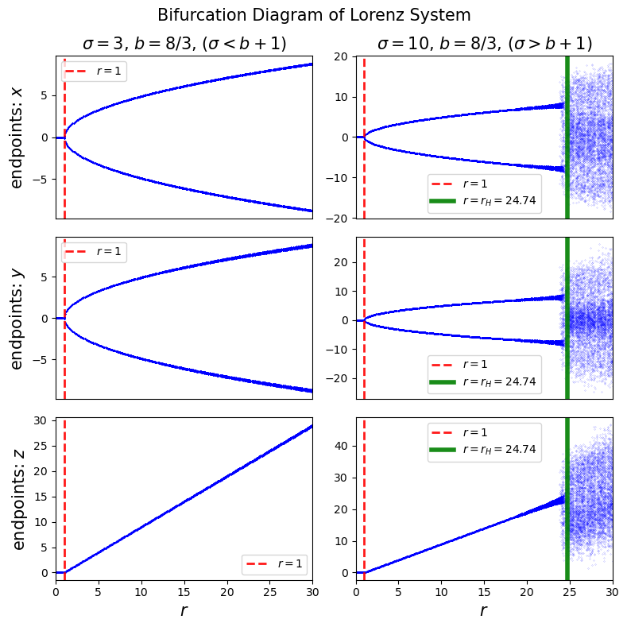

```python
fig, axes = plt.subplots(3, 2, figsize=(8, 8))
fig.suptitle('Bifurcation Diagram of Lorenz System', fontsize=15)
for j, (_sigma, _state) in enumerate(state.items()):
    for i, s in enumerate(list('xyz')):
        axes[i, j].plot(_state['r'], _state[s], 'bo', markersize=.1)
        axes[i, j].set_xlim(0, 30)
        axes[i, j].axvline(1, c='r', linestyle='--', linewidth=2, alpha=.9, label=r'$r=1$')
        if i == 0:
            axes[i, j].set_title(fr'$\sigma={_sigma}$, $b=8/3$, $(\sigma{'>' if j == 1 else '<'}b+1)$', fontsize=15)
        if i < 2:
            axes[i, j].xaxis.set_visible(False)
        if i == 2:
            axes[i, j].set_xlabel(r'$r$', fontsize=15)
        if j == 0:
            axes[i, j].set_ylabel(f"endpoints: ${s}$", fontsize=15)
        if j == 1:
            r_H = _sigma * (_sigma + b + 3) / (_sigma - b - 1)
            axes[i, j].axvline(r_H, c='g', linewidth=4, alpha=.9, label=fr'$r=r_H={r_H:.2f}$')
        axes[i, j].legend()
plt.tight_layout()
```

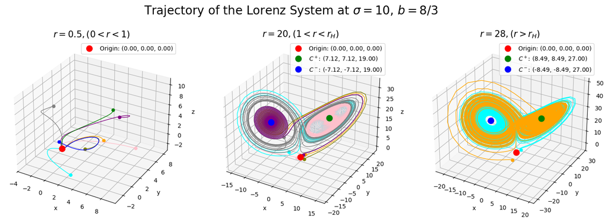

```python
r_values = [0.5, 20, 28]
n_values = [8, 6, 2]
fixed_points = [[(0, 0, 0), (np.sqrt(b*(r-1)), np.sqrt(b*(r-1)), r-1), (-np.sqrt(b*(r-1)), -np.sqrt(b*(r-1)), r-1)] if r > 1 else [(0, 0, 0)] for r in r_values]
fixed_points_name = ['Origin', r'$C^+$', r'$C^-$']
colors = ['r', 'g', 'b', 'pink', 'purple', 'olive', 'gray', 'orange', 'cyan']
titles = [rf'$r={r_values[0]},(0<r<1)$', rf'$r={r_values[1]},(1<r<r_H)$', rf'$r={r_values[2]},(r>r_H)$']
fig = plt.figure(figsize=(18, 6))
fig.suptitle(rf'Trajectory of the Lorenz System at $\sigma={sigma[1]}$, $b=8/3$', fontsize=20)
for i, (n, r, fp) in enumerate(zip(n_values, r_values, fixed_points)):
    t_span = [0, 100]
    num_points = 5000
    t_eval = np.linspace(t_span[0], t_span[1], num_points)
    ax = fig.add_subplot(1, 3, i + 1, projection='3d')
    for _ in range(n):
        initial_state_chaos = np.random.randn(3) * 4
        sol = solve_ivp(lorenz, t_span, initial_state_chaos, args=(r, sigma[1], b), t_eval=t_eval)
        x, y, z = sol.y
        ax.plot(x, y, z, lw=1, c=colors[-1-_])
        ax.plot(x[0], y[0], z[0], 'o', c=colors[-1-_], markersize=5)
    for j, p in enumerate(fp):
        ax.plot(p[0], p[1], p[2], f'{colors[j]}o', markersize=10, label=f'{fixed_points_name[j]}: ({p[0]:.2f}, {p[1]:.2f}, {p[2]:.2f})')

    ax.set_title(titles[i], fontsize=15)
    ax.set_xlabel('x')
    ax.set_ylabel('y')
    ax.set_zlabel('z')
    ax.legend()
```

#### 3.3. Bonus exercise: Show that there can be no cycles for $ r < 1 $. (Hint: The function $ V(x, y, z) = \frac{x^2}{\sigma} + y^2 + z^2 $ might be of help.)

Consider $ V(x, y, z) = \frac{x^2}{\sigma} + y^2 + z^2 $. Take the derivative: $$\begin{aligned} \frac{1}{2}\dot V &= \frac{1}{\sigma} x\dot x + y\dot y + z\dot z\\ &= (y - x)x + (rx - y - xz)y + (zy - b)z \\ &= (r + 1) xy - x^2 - y^2 - bz^2\\ &= -\left[x-\frac{r+1}{2}y\right]^2-\left[1-\left(\frac{r+1}{2}\right)^2\right]y^2-bz^2. \end{aligned}$$ For $r<1$, we get $\dot V<0$ when $(x,y,z)\neq(0,0,0)$ and $\dot V=0$ holds only when $(x,y,z)=(0,0,0)$. Thus the origin is globally stable and there can be no cycles.